# Deep Learning- 課程 10－Deep Learning- An Introduction To Deep Learning Network - Keras Build A Deep Network Part- 02 - Python Tutorial

''' 人工智慧- 進階課程 A.I Tutorials - Advanced Course - Deep Learning 教程 ''' 05 - 深度學習 教程 課程 10－Deep Learning- An Introduction To Deep Learning Network - Keras Build A Deep Network Part- 02 - 深度學習 模型 介紹 程式範例 - Keras 創建 - Vgg16 Model 模型 ''' ''' >> 資料準備 >> 你我互動學習園地- 進階課程 Advanced Course >> https://interactiveuandmetutorialsac.weebly.com/ >> 你我互動學習園地 >> https://interactiveuandmetutorials.weebly.com/ >> Python 程式語言 設計 >> https://pythonprogrammingtutorials.weebly.com/ >> 目錄結構 : >> Deep Learning- 課程 10 - Deep Learning - An Introduction To Deep Learning Network.zip 檔案路徑/ ├── 課程 10 - Deep Learning - An Introduction To Deep Learning Network.ipynb ''' ''' Keras >> https://keras.io/ '''

```python
- CNN 經典的模型 - Model
```

[figure not shown]

''' - LeNet Architecture - 利用 - 卷積 跟 池化 - 全連結層 - 分類 '''

[figure not shown]

''' - AlexNet Architecture - 非線性激活函數 (Activation function) - Relu - AlexNet 以前 - 大部分的網路 - 都是用 - tanh 作激活函數 - Data Augmentation / Dropout - 防止 Overfitting - GPU - 並行運算 '''

[figure not shown]

''' - VGG16 Architecture - VGGNet 跟 AlexNet 之間 - 並沒有什麼 - 太大的差異 - 網路深度 - 變深 - 進而得到 - 更好的結果 '''

[figure not shown]

''' - Inception (GoogLeNet) Architecture - GoogleNet - 有幾種不同的地方 - 不是像 VGG 或是 AlexNet 加深網路的概念 - 是加入了一個 - 叫做 Inception - 的結構 - 取代了原本單純的卷積層 (但- 也是利用卷積 -達成) - 而 訓練參數 - 比 AlexNet 少上好幾倍 - 而且準確率 - 相對更好 - GoogleNet 有以下幾種不同的地方 - 將單純的卷積層 跟 池化層 - 改成 - Inception 架構 - 最後分類 - 使用average pooling來替代 - 全連結層 - 網路加入- 2個 輔助分類器 - 為了 避免梯度消失 '''

[figure not shown]

''' - GoogLeNet - 最重要 - Inception 架構 - 將 3種 convolution跟一個pooling疊在一起 - 增加了 網路 - 的寬度 - 堆疊一起後 - 能擷取輸入圖片 - 更多的 細節訊息 跟 特徵 - 為什麼要加一個 1x1的 卷積 - 的目 - 減少圖片的 維度 - 減少 訓練參數 - GoogleNet - 有幾種不同的地方 - 單純的 卷積層 跟 池化層 - 改成 Inception架構 - 最後分類時 - 使用 Average pooling - 替代了全連結層 FC - 網路加入了2個輔助分類器 - 避免 梯度消失的情況 '''

[figure not shown]

''' - ResNet 殘差 Architecture 網路 - 深度學習 是不是越深就越好呢 - 論文 - 的圖 - 56層的網路 結果 - 比 20層的網路 - 差 - 經過實驗後發現 - 網路層數的增加 - 可以有效的超加 - 準確率 - 如果到達一定的層數後 - 訓練的準確率 - 就會開始下降了 - 代表 - 說如果網路過深 - 會變得更加難以訓練 '''

[figure not shown]

''' - 深度殘差 Architecture 網路 - Deep Residual Network - DRN - -殘差 - 去掉了相同的主體部份，進而突顯出微小的變化 - 殘差網路 - 輸出的部份加入了一個x - 輸出H(x)就會變成 H(x)= F(x)+ x - 那如果把 F(x)=0 時 - 會變成 H(x) = x - 就是前面所說的恆等映射 - 殘差網路就變成訓練 F(x):H(x)-x - 目標就是要將 F(x) 趨近於 0 - 才可以使網路加深 - 準確率不會下降 - 假設輸入x = 5 - 經過第一層出來後的 H(x)為 5.1，那麼 F(x) = 5.1–5 = 0.1 - 經過第二層出來後的 H(x)為 5.2，那麼 F(x) = 5.2–5 = 0.2 - v 原本網路的 變化率 - 是 (5.2–5.1)/5.1 = 1.96% - 殘差網路的變化率是 - (0.2–0.1)/0.1 = 100% - 殘差網路對於調整參數的效果會更好 - 殘差去掉了相同的主體部份 - 進而突顯出微小的變化 '''

[figure not shown]

# 程式範例

```python
- Keras
    - 創建 深度學習 模型
    - VGG 16

-  Keras 參考文顯 - [keras.io](https://keras.io/applications/#vgg16)
```

[figure not shown]

''' >> 構建 - VGG 16 深度學習 模型 - 輸入圖像尺寸 - Input size - 224 x 224 - 感受過瀘器 - Receptive Field - 大小 - 3 x 3 - 卷積步長 - Stride - 1個 像素 - 填充 - padding - 1 - - 感受過瀘器 - 3 x 3 - 池化層 - 2 × 2 步長 - Stride - 2 像素 Pixel - 兩個 完全連接層 FC - 每層 4096個 神經元 - 最後一層 - 1000個 神經元 - Softmax 分類層 - 1000個 - ImageNet 類別 - 激勵函數 - ReLU '''

# Import 相關函式庫

```python
import platform
```

```python
!python -V
platform.python_version()
```

```
Python 3.7.3
```

```
'3.7.3'
```

```python
import tensorflow
import keras
print("Platform: {}".format(platform.platform()))
print("Tensorflow version: {}".format(tensorflow.__version__))
print("Keras version: {}".format(keras.__version__))
```

```
Platform: Windows-10-10.0.18362-SP0
Tensorflow version: 1.14.0
Keras version: 2.2.4
```

```python
%matplotlib inline
import matplotlib.pyplot as plt
import matplotlib.image as mpimg
import numpy as np
from IPython.display import Image
```

- Install plot_model/ Image
  - pip install graphviz
  - pip install pydot

## 創建模型 (Sequential)

```python
import pydot
from IPython.display import Image
from keras.utils import plot_model
```

```python
import keras
from keras.models import Sequential
from keras.layers import Dense, Activation, Dropout, Flatten
from keras.layers import Conv2D, MaxPool2D
from keras.utils import plot_model

# 定義輸入
input_shape = (224, 224, 3) # RGB影像 224x224 (height, width, channel)

# 使用 - 序貫模型(Sequential)來定義
model = Sequential(name='vgg16-sequential')

# 第1個卷積區塊 (block1)
model.add(Conv2D(64, (3, 3), padding='same', activation='relu', input_shape=input_shape, name='block1_conv1'))
model.add(Conv2D(64, (3, 3), padding='same', activation='relu', name='block1_conv2'))
model.add(MaxPool2D((2, 2), strides=(2, 2), name='block1_pool'))

# 第2個卷積區塊 (block2)
model.add(Conv2D(128, (3, 3), padding='same', activation='relu', name='block2_conv1'))
model.add(Conv2D(128, (3, 3), padding='same', activation='relu', name='block2_conv2'))
model.add(MaxPool2D((2, 2), strides=(2, 2), name='block2_pool'))

# 第3個卷積區塊 (block3)
model.add(Conv2D(256, (3, 3), padding='same', activation='relu', name='block3_conv1'))
model.add(Conv2D(256, (3, 3), padding='same', activation='relu', name='block3_conv2'))
model.add(Conv2D(256, (3, 3), padding='same', activation='relu', name='block3_conv3'))
model.add(MaxPool2D((2, 2), strides=(2, 2), name='block3_pool'))

# 第4個卷積區塊 (block4)
model.add(Conv2D(512, (3, 3), padding='same', activation='relu', name='block4_conv1'))
model.add(Conv2D(512, (3, 3), padding='same', activation='relu', name='block4_conv2'))
model.add(Conv2D(512, (3, 3), padding='same', activation='relu', name='block4_conv3'))
model.add(MaxPool2D((2, 2), strides=(2, 2), name='block4_pool'))

# 第5個卷積區塊 (block5)
model.add(Conv2D(512, (3, 3), padding='same', activation='relu', name='block5_conv1'))
model.add(Conv2D(512, (3, 3), padding='same', activation='relu', name='block5_conv2'))
model.add(Conv2D(512, (3, 3), padding='same', activation='relu', name='block5_conv3'))
model.add(MaxPool2D((2, 2), strides=(2, 2), name='block5_pool'))

# 前饋全連接區塊
model.add(Flatten(name='flatten'))
model.add(Dense(4096, activation='relu', name='fc1'))
model.add(Dense(4096, activation='relu', name='fc2'))
model.add(Dense(1000, activation='softmax', name='predictions'))

# 打印網絡結構
model.summary()

# plot graph
plot_model(model, to_file='vgg16model.png')
```

```
_________________________________________________________________
Layer (type)                 Output Shape              Param #
=================================================================
block1_conv1 (Conv2D)        (None, 224, 224, 64)      1792
_________________________________________________________________
block1_conv2 (Conv2D)        (None, 224, 224, 64)      36928
_________________________________________________________________
block1_pool (MaxPooling2D)   (None, 112, 112, 64)      0
_________________________________________________________________
block2_conv1 (Conv2D)        (None, 112, 112, 128)     73856
_________________________________________________________________
block2_conv2 (Conv2D)        (None, 112, 112, 128)     147584
_________________________________________________________________
block2_pool (MaxPooling2D)   (None, 56, 56, 128)       0
_________________________________________________________________
block3_conv1 (Conv2D)        (None, 56, 56, 256)       295168
_________________________________________________________________
block3_conv2 (Conv2D)        (None, 56, 56, 256)       590080
_________________________________________________________________
block3_conv3 (Conv2D)        (None, 56, 56, 256)       590080
_________________________________________________________________
block3_pool (MaxPooling2D)   (None, 28, 28, 256)       0
_________________________________________________________________
block4_conv1 (Conv2D)        (None, 28, 28, 512)       1180160
_________________________________________________________________
block4_conv2 (Conv2D)        (None, 28, 28, 512)       2359808
_________________________________________________________________
block4_conv3 (Conv2D)        (None, 28, 28, 512)       2359808
_________________________________________________________________
block4_pool (MaxPooling2D)   (None, 14, 14, 512)       0
_________________________________________________________________
block5_conv1 (Conv2D)        (None, 14, 14, 512)       2359808
_________________________________________________________________
block5_conv2 (Conv2D)        (None, 14, 14, 512)       2359808
_________________________________________________________________
block5_conv3 (Conv2D)        (None, 14, 14, 512)       2359808
_________________________________________________________________
block5_pool (MaxPooling2D)   (None, 7, 7, 512)         0
_________________________________________________________________
flatten (Flatten)            (None, 25088)             0
_________________________________________________________________
fc1 (Dense)                  (None, 4096)              102764544
_________________________________________________________________
fc2 (Dense)                  (None, 4096)              16781312
_________________________________________________________________
predictions (Dense)          (None, 1000)              4097000
=================================================================
Total params: 138,357,544
Trainable params: 138,357,544
Non-trainable params: 0
_________________________________________________________________
```

## 模型訓練 - 參數總數

- 論文 網絡結構參數 - 138 百萬
  - vgg16model 構建的模型 - Total params: 138,357,544
    - 138,357,544參數論文提及的138百萬的訓練參數。

[figure not shown]

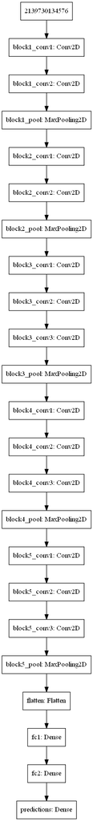

```python
# 顯示網絡 拓撲圖
Image('vgg16model.png')
```